# Bartik

Sam Gyetvay

12/10/2018

### Warm Up: 2SLS

The paper has to do with 2SLS, and this is the first time I’ve worked with R, so I start with a basic exercise: simulating a univariate 2SLS and running a Monte-Carlo on it

$$\begin{align*}
y &= \alpha + \beta x + \epsilon \\
x &= \delta + \gamma z + \zeta
\end{align*}$$

Generating the data:

```r
alpha = 1
beta = 2

simulate_data <- function(N) {
df <- crossing(location = 1:N) %>%
  mutate(epsilon = rnorm(N),
         instrument = 0.5*rnorm(N),
         treatment = 1*epsilon + 1*instrument + 0.05*rnorm(N),
         outcome = alpha + beta*treatment + epsilon)
return(df)
}

df <- simulate_data(100)
head(df)
```

```
## # A tibble: 6 x 5
##   location epsilon instrument treatment outcome
##      <int>   <dbl>      <dbl>     <dbl>   <dbl>
## 1        1  -0.511     0.408    -0.0589   0.371
## 2        2  -1.26     -0.0133   -1.26    -2.79
## 3        3  -1.35      0.0131   -1.40    -3.15
## 4        4   0.938     0.225     1.01     3.96
## 5        5   0.276    -0.670    -0.418    0.441
## 6        6   0.280    -0.786    -0.457    0.366
```

We need to use IV if $Cov(x,\epsilon) \not= 0$. IV is valid if it is relevant ($Cov(x,z) \not= 0$) and satisfies the *exclusion restriction* $Cov(z,\epsilon) = 0$:

```r
cov(df$treatment, df$epsilon) #need IV
```

```
## [1] 1.177968
```

```r
cov(df$treatment, df$instrument) #relevance
```

```
## [1] 0.3043257
```

```r
cov(df$instrument, df$epsilon) #exclusion
```

```
## [1] 0.0630236
```

In this case, OLS is biased but 2SLS is not

```r
#ols
ols <- function(df) {
lm(df$outcome ~ df$treatment)$coefficients[2]
}

#2sls
twosls <- function(df) {
coefficients(lm(df$outcome ~ predict(lm(df$treatment ~ df$instrument))))[2]
}

cat("The OLS estimate is ", ols(df), " and the 2SLS estimate is ", twosls(df), ".")
```

```
## The OLS estimate is  2.794659  and the 2SLS estimate is  2.207093 .
```

To make sure these results were not haphazard, I run a Monte-Carlo simulation. To do this I use the R functions `simulate_data`, `twosls` and `ols` I created above evaluate them $M$ times. I plot the results in a smoothed density plot.

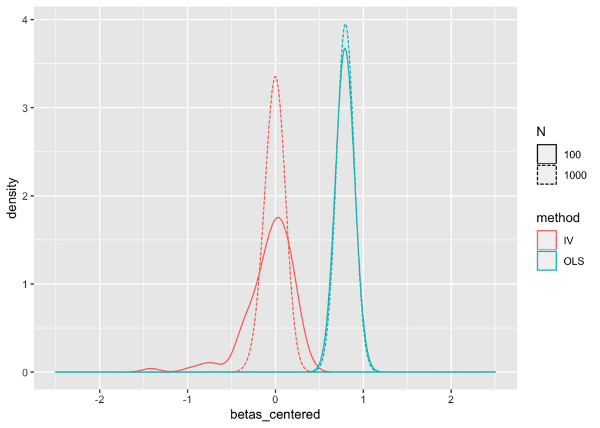

```r
M = 100 #number of monte-carlos

betas <- c()
method <- c()
sample_size <- c()

for (n in c(100,1000)) {
  for (i in seq(M)) {
    betas <- c(betas, twosls(simulate_data(n)))
    method <- c(method, "IV")
    sample_size <- c(sample_size,n)
  }
    for (i in seq(M)) {
    betas <- c(betas, ols(simulate_data(n)))
    method <- c(method, "OLS")
    sample_size <- c(sample_size,n)
  }
}


plotdata <- as.data.frame(betas)
plotdata$betas_centered <- betas-beta
plotdata$method <- method
plotdata$sample_size <- sample_size

ggplot(plotdata, aes(x=betas_centered, color=method, linetype = as.factor(sample_size))) +
  scale_linetype_discrete(name="N") +
  geom_density(alpha=0.33, position="identity", bw=0.1, fill=NA) +
  xlim(c(-2.5,2.5))
```

Cool. Now I’m ready to move on to the paper.

### Borusyak, Hull, Jaravel (2018)

#### Some Theory

Start out with a basic cross-sectional shift-share set up. $\ell = 1, ..., L$ indexes locations, $y_\ell$ are outcomes, $x_\ell$ are treatment, $w_\ell$ are vectors of controls, and $\epsilon_\ell$ are residuals. The regression equation is

$$y_\ell = \beta x_\ell + w_\ell'\gamma + \epsilon_\ell$$

where $E[\epsilon_\ell] = E[w_\ell\epsilon_\ell] = 0$ but $E[x_\ell\epsilon_\ell] \not= 0$. Construct the shift-share instrument $z_\ell$ from industry (indexed by $n = 1, ..., N$) level shocks (shift) $g_n$ and weights (local industry share) $s_{\ell n}$:

$$z_\ell = \sum_{n=1}^N s_{\ell n} g_n$$

Now do the usual IV stuff. We first regress

$$x_\ell = \delta z_\ell + w_\ell'\gamma_1 e_\ell$$

Then get $\hat{x}_\ell = \hat{\delta}z_\ell$ and regress

$$y_\ell = \beta \hat{x}_\ell + w_\ell'\gamma_2 + \epsilon_\ell$$

to get

$$\hat{\beta}_\ell
=
\frac{\frac{1}{L}\sum_\ell z_\ell y_\ell^\perp}{\frac{1}{L}\sum_\ell z_\ell x_\ell^\perp}$$

where $x_\ell^\perp = x_\ell - \hat{x}_\ell$ and $y_\ell^\perp = y_\ell - \hat{y}_\ell$. This is the typical way to do shift-share; a regression at the location level. The core insight of BHJ is that this is equivalent to doing 2SLS procedure at the industry level. Watch this:

$$\begin{align*}
\hat{\beta}_\ell
&=
\frac{\frac{1}{L}\sum_\ell z_\ell y_\ell^\perp}{\frac{1}{L}\sum_\ell z_\ell x_\ell^\perp} \\
&=
\frac{\frac{1}{L}\sum_\ell \big(\sum_n s_{\ell n} g_n\big) y_\ell^\perp}{\frac{1}{L}\sum_\ell \big(\sum_n s_{\ell n} g_n\big) x_\ell^\perp} \\
&=
\frac{\sum_n g_n \big(\frac{1}{L}\sum_\ell s_{\ell n} y_\ell^\perp \big) }{\sum_n g_n \big(\frac{1}{L}\sum_\ell s_{\ell n} x_\ell^\perp \big) } \\
&=
\frac{\sum_n g_n \big(\frac{1}{L}\sum_\ell s_{\ell n} \big) \big[\big(\frac{1}{L}\sum_\ell s_{\ell n} y_\ell^\perp\big)/\big( \frac{1}{L}\sum_\ell s_{\ell n}\big)\big]}{\sum_n g_n \big(\frac{1}{L}\sum_\ell s_{\ell n} \big) \big[\big(\frac{1}{L}\sum_\ell s_{\ell n} x_\ell^\perp\big)/\big( \frac{1}{L}\sum_\ell s_{\ell n}\big)\big]} \\
&=
\frac{\sum_n g_n \hat{s}_n\bar{y}_n^\perp}{\sum_n g_n\hat{s}_n \bar{x}_n^\perp}
=
\hat{\beta}_n
\end{align*}$$

where $\hat{s}_n$ is average exposure to industry $n$, and $\bar{x}_n$, $\bar{y}_n$ are weighted averages of $x_\ell$, $y_\ell$ where larger weights are given to industries with more exposure. So we can get $\hat{\beta}_n$ from $\hat{s}_n$-weighted 2SLS of with instrument $g_n$ and second stage

$$\bar{y}^\perp_n = \alpha + \beta\bar{x}_n^\perp + \bar{\epsilon}^\perp_n$$

#### A Simulation to show Numerical Equivalence

I’ll now simulate a cross-sectional Bartik data-set similar to one that an applied researcher would have, and illustrate the numerical equivalence betwen $\hat{\beta}_\ell$ and $\hat{\beta}_n$.

```r
L = 50 #number of locations
N = 100 #number of industries

alpha = 1 #intercept
beta = 2 #coefficient of interest
gamma = 3 #controls

df <- crossing(location = 1:L,
               industry = 1:N) %>%
  group_by(location) %>%
  mutate(control = rnorm(1),
         error = runif(1),
         treatment = 0.5*error + runif(1),
         outcome = alpha + beta*treatment + gamma*control + error) %>%
  group_by(industry) %>%
  mutate(shock = 1.5*rnorm(1),
         share = runif(L)) %>%
  group_by(location) %>%
  mutate(share = share/sum(share))


df %>% arrange(location) %>%  head()
```

```
## # A tibble: 6 x 8
## # Groups:   location [1]
##   location industry control error treatment outcome  shock   share
##      <int>    <int>   <dbl> <dbl>     <dbl>   <dbl>  <dbl>   <dbl>
## 1        1        1  -0.211 0.308      1.01    2.70 0.0325 0.00379
## 2        1        2  -0.211 0.308      1.01    2.70 0.647  0.00888
## 3        1        3  -0.211 0.308      1.01    2.70 0.0965 0.00142
## 4        1        4  -0.211 0.308      1.01    2.70 2.62   0.00332
## 5        1        5  -0.211 0.308      1.01    2.70 0.179  0.00895
## 6        1        6  -0.211 0.308      1.01    2.70 0.919  0.00603
```

I simulated data in this “long” form (with $L*N$ rows) because it seems like that’s the way a researcher would get it in, and it’s easy to calculate both the standard shift-share, and the industry-level shiftware with data in this form. It’s also conceivable that data could come in “wide” form ($L$ rows, with industry-level variables as columns) but I won’t deal with that case.

Now I’ll collapse this into a dataframe `dfL` with $L$ rows and create the instrument $z_\ell$:

```r
dfL <- df %>%
mutate(shiftshare = share*shock) %>%
  group_by(location) %>%
mutate(shiftshare = sum(shiftshare)) %>%
summarise(outcome = mean(outcome),
          control = mean(control),
          treatment = mean(treatment),
          shiftshare = mean(shiftshare))

dfL %>%  arrange(location) %>% head()
```

```
## # A tibble: 6 x 5
##   location outcome control treatment shiftshare
##      <int>   <dbl>   <dbl>     <dbl>      <dbl>
## 1        1   2.70  -0.211      1.01    -0.0834
## 2        2   2.60  -0.0839     0.728   -0.0116
## 3        3  -2.90  -1.77       0.531    0.0244
## 4        4   7.76   1.70       0.787   -0.0401
## 5        5   6.67   1.47       0.465   -0.00769
## 6        6   0.217 -0.748      0.671    0.0854
```

Then run 2SLS to get $\hat{\beta}_\ell$:

```r
#first stage
dfL$treatment_hat <- predict(lm(dfL$treatment ~ dfL$shiftshare + dfL$control))

#second stage
location_reg <- lm(dfL$outcome ~  dfL$treatment_hat + dfL$control)
```

Now collapse `df` into a dataframe `dfN` with $N$ rows:

```r
dfL$treatment_perp <- dfL$treatment - predict(lm(dfL$treatment ~ dfL$control))
dfL$outcome_perp <- dfL$outcome - predict(lm(dfL$outcome ~ dfL$control))

df <- merge(df,select(dfL,location,outcome_perp,treatment_perp))

dfN <- df %>%
  group_by(industry) %>%
mutate(industry_share = mean(share)) %>%
  group_by(location) %>%
  mutate(outcome_ind = outcome_perp*share/(industry_share),
         treatment_ind = treatment_perp*share/(industry_share)) %>%
  group_by(industry) %>%
  summarise(outcome = mean(outcome_ind),
            treatment = mean(treatment_ind),
            shock = mean(shock),
            wght = mean(industry_share))

dfN %>%  arrange(industry) %>% head()
```

```
## # A tibble: 6 x 5
##   industry outcome treatment  shock    wght
##      <int>   <dbl>     <dbl>  <dbl>   <dbl>
## 1        1  0.0724    0.0283 0.0325 0.0102
## 2        2 -0.0467   -0.0169 0.647  0.00963
## 3        3 -0.0625   -0.0221 0.0965 0.00963
## 4        4  0.0197    0.0133 2.62   0.00980
## 5        5 -0.0568   -0.0171 0.179  0.00940
## 6        6  0.0674    0.0349 0.919  0.00981
```

and run 2SLS to get $\hat{\beta}_n$:

```r
#first stage
dfN$treatment_hat <- predict(lm(dfN$treatment ~ dfN$shock, weights = dfN$wght))

#second stage
industry_reg <- lm(dfN$outcome ~ dfN$treatment_hat, weights = dfN$wght)

cat("The estimate from the location-level regression is ", location_reg$coefficients[2], "and the estimate from the industry-level regression is ", industry_reg$coefficients[2])
```

```
## The estimate from the location-level regression is  1.541547 and the estimate from the industry-level regression is  1.541547
```

This shows the numerical equivalence.

#### More Theory

The numerical equivalence is interesting because it gives us a new sufficient condition for identification using Bartik instruments: validity of industry-level shocks $g_n$, the instrument in the industry-level data. Such an assumption is natural in many settings, such as in Autor, Dorn & Hansen (2013) where $g_n$ is constructed from industry-level Chinese import penetratation to non-US countries.

In this section I give a formal statement of BHJ’s “shock exogeneity” condition, which they show is equivalent to validity of $z_\ell$. In the next section I do some Monte Carlo simulations to show what happens when we violate shock exogeneity.

The shift-share $z_\ell$ is valid if $E[z_\ell\epsilon_\ell]=0$. Now do some arithmetic similar to above when we showed $\hat{\beta}_\ell = \hat{\beta}_n$:

$$E[z_\ell\epsilon_\ell]
=
E\Big[ \sum_n s_{\ell n}g_n \epsilon_\ell \Big]
=
\sum_n \underbrace{E[s_{\ell n}]}_{s_n}g_n\underbrace{E[s_{\ell n}\epsilon_\ell]/E[s_{\ell n}]}_{\phi_n}
=
\sum_n s_n g_n \phi_n$$
where $s_n$ and $\phi_n$ are the population-analogues of $\hat{s}_n$ and $\bar{\epsilon}_n^\perp$. Assuming a LLN holds, BHJ’s “shock orthogonality” condition is
$$\sum_n s_ng_n\phi_n \rightarrow 0$$

BHJ show that shock orthogonality is satisfied under the following assumptions

- **A1** $E[g_n|\phi_n] = \mu$
- **A2** $E[(g_n - \mu)(g_m - \mu)|\phi_n,\phi_m] = 0$ for $m \not= n$
- **A3** $\sum_n s_n^2 \rightarrow 0$
- **A4** $E[\phi_n^4]$, $E[(g_n - \mu)^4] < \infty$.

In words, A1 states that every industry faces the same expected shock $\mu$ regardless of its $\phi_n$ (they are “as-good-as-randomly assigned.”) Suppose the $s_n$ are non-random. In the proof, you use A1 to show

$$E[\sum_n g_n s_n \phi_n] = \sum E[E[g_n|\phi_n] s_n \phi_n] = \mu E[s_n\phi_n] = E[\epsilon_\ell]\mu = 0$$

BHJ then show $Var[\sum_n g_n s_n \phi_n] \rightarrow 0$. To do this they use A2 (which says that shocks are mutually uncorrelated given unobservables), A3 (which says that shock exposure is not too concentrated among a small set of industries) and A4 is just there so that they can use the Cauchy-Schwarz inequality.

I’ll now do a Monte-Carlo simulation where I relax some of these assumptions and show that $\hat{\beta}_n$ no longer converges to true $\beta$. To do this, I’m going to generate data in a different way than I did above. I will create $\epsilon_\ell$, $s_{\ell n}$ at the local level, but I’m going to “cheat” and skip straight to generating $y_n$ and $x_n$ at the industry level. I’m doing this because it’s not obvious (to me) how to construct local-level $x_\ell$, $\epsilon_\ell$ that violate exclusion restrictions with industry-level $g_n$. However, in my defence, this confusion reinforces the point of the paper: Bartik exclusion restrictions are non-intuitive at the local level. I’m also going to exclude controls $w_\ell$ for simplicity.

First, create data where **A1-A4** are all satisfied and very that the IV is consistent:

```r
rm(list = ls())

L = 25
N = 1000
alpha = 1
beta = 2

#create theta_n, s_n


df <- crossing(location = 1:L,
               industry = 1:N) %>%
  group_by(location) %>%
  mutate(share = runif(N),
         error = 10*rnorm(N),
         share = share/sum(share),
         theta = share*error/sum(share)) %>%
  group_by(industry) %>%
  summarise(theta = sum(theta),
            share = sum(share))

dfN <- df %>%
  mutate(shock = rnorm(N),
         treatment = 1*shock + 2*theta + 0.5*rnorm(N),
         outcome = alpha + beta*treatment + 5*theta)

beta <- coefficients(lm(dfN$outcome ~ predict(lm(dfN$treatment ~ dfN$shock))))[2]

cat("The estimate of beta when assumptions A1-A4 hold is ", beta, "which is close to its true value of 2.")
```

```
## The estimate of beta when assumptions A1-A4 hold is  2.00529 which is close to its true value of 2.
```

Now weaken A2 and make the shocks auto-correlated across industries:

```r
dfN <- df %>%
  mutate(theta_lag = lag(theta),
         shock = 0.5*theta + 0.5*theta_lag + rnorm(N),
         treatment = 1*shock + 2*theta + 0.5*rnorm(N),
         outcome = alpha + beta*treatment + 5*theta)

dfN <- na.omit(dfN)

beta <- coefficients(lm(dfN$outcome ~ predict(lm(dfN$treatment ~ dfN$shock))))[2]

cat("The estimate of beta when assumptions A2 fails because shocks are auto-correlated across industries is ", beta, "which is far from its true value of 2.")
```

[output not shown]

Now weaken A3 and make the shocks concentrated in a small number of industries:

```r
df <- crossing(location = 1:L,
               industry = 1:N) %>%
  group_by(location) %>%
  mutate(share = runif(N) + ifelse(industry <= 5, 10,0),
         error = 10*rnorm(N),
         share = share/sum(share),
         theta = share*error/sum(share)) %>%
  group_by(industry) %>%
  summarise(theta = sum(theta),
            share = sum(share))

dfN <- df %>%
  mutate(shock = rnorm(N),
         treatment = 1*shock + 2*theta + 0.5*rnorm(N),
         outcome = alpha + beta*treatment + 5*theta)

beta <- coefficients(lm(dfN$outcome ~ predict(lm(dfN$treatment ~ dfN$shock))))[2]

cat("The estimate of beta when assumptions A3 fails because shocks are concentrated in a small number of industries is ", beta, "which is far from its true value of 2.")
```

[output not shown]

The theorem BHJ prove says that $\hat{\beta}_n$ is *consistent* under A1-A4. Since running a similation with $N = \infty$ wouldn’t be finished before the due-date of this assignment, I’ll instead run a monte-carlo and show that we don’t get convergence doesn’t happen as I boost $N$. Note that to violate A3 as I increase $N$ I also need to increase the number of concentrated industries.

Define functions to generate bad data:

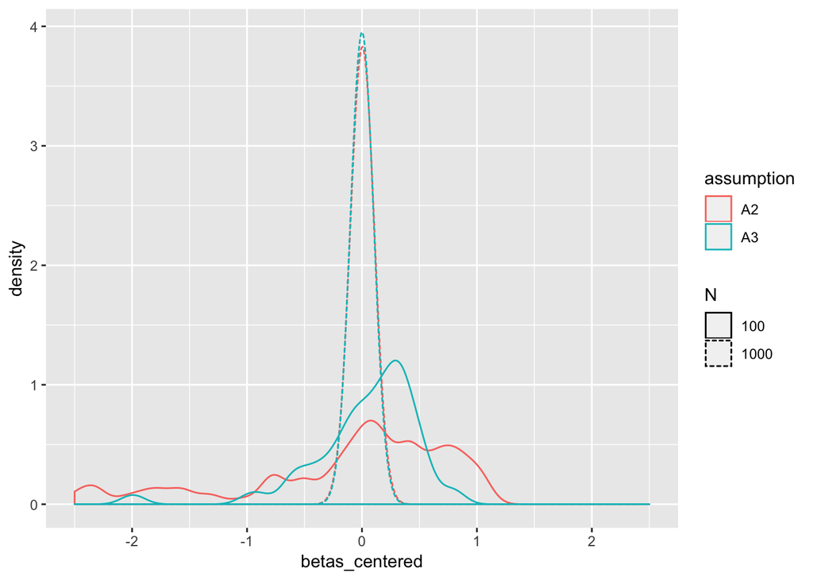

```r
rm(list=ls())

alpha = 1
beta = 2

M = 100 # number of montecarlos
L = 50 # number of locations

autocorr_shocks <- function(N) {
  df <- crossing(location = 1:L,
               industry = 1:N) %>%
  group_by(location) %>%
  mutate(share = runif(N),
         error = 10*rnorm(N),
         share = share/sum(share),
         theta = share*error/sum(share)) %>%
  group_by(industry) %>%
  summarise(theta = sum(theta),
            share = sum(share))
dfN <- df %>%
  mutate(shock = rnorm(N),
         treatment = 1*shock + 2*theta + 0.5*rnorm(N),
         outcome = alpha + beta*treatment + 5*theta)
return(dfN)
}

concentrated_shocks <- function(N) {
df <- crossing(location = 1:L,
               industry = 1:N) %>%
  group_by(location) %>%
  mutate(share = runif(N) + ifelse(industry <= N/20, 10,0),
         error = 10*rnorm(N),
         share = share/sum(share),
         theta = share*error/sum(share)) %>%
  group_by(industry) %>%
  summarise(theta = sum(theta),
            share = sum(share))
dfN <- df %>%
  mutate(shock = rnorm(N),
         treatment = 1*shock + 2*theta + 0.5*rnorm(N),
         outcome = alpha + beta*treatment + 5*theta)
return(dfN)
}

twosls <- function(df) {
coefficients(lm(df$outcome ~ predict(lm(df$treatment ~ df$shock))))[2]
}


betas <- c()
assumption <- c()
sample_size <- c()

for (n in c(100,1000)) {
  for (i in seq(M)) {
    betas <- c(betas, twosls(autocorr_shocks(n)))
    assumption <- c("A2", assumption)
    sample_size <- c(sample_size, n)
  }
  for (i in seq(M)) {
    betas <- c(betas, twosls(concentrated_shocks(n)))
    assumption <- c("A3", assumption)
    sample_size <- c(sample_size, n)
  }
}

plotdata <- as.data.frame(betas)
plotdata$betas_centered <- betas-beta
plotdata$assumption <- assumption
plotdata$sample_size <- sample_size

ggplot(plotdata, aes(x=betas_centered, color=assumption, linetype = as.factor(sample_size))) +
  scale_linetype_discrete(name="N") +
  geom_density(alpha=0.33, position="identity", bw=0.1, fill=NA) +
  xlim(c(-2.5,2.5))
```

Looks like both actually *did* converge once I put $N=1000$, despite the assumptions being wrong. I suppose this means the assumptions in BHJ’s proof can be weakened.